# Отчёт по лабораторной работе №5. Задача классификации. Детектирование букв с помощью нейронной сети.

# Выполнили: Патина Кристина, Рагузова Татьяна 16ПМИ

```python
import numpy as np
import pandas as pd
import matplotlib.pyplot as plt
import scipy
from sklearn.svm import SVC
from sklearn.ensemble import RandomForestClassifier, GradientBoostingClassifier
import tensorflow as tf
import warnings
warnings.filterwarnings('ignore')
from keras.utils import np_utils
from keras.models import Sequential
from keras.layers import Dense, Dropout, Activation
from sklearn.metrics import confusion_matrix
import itertools
from sklearn.decomposition import PCA
from sklearn.multiclass import OneVsRestClassifier
from sklearn.preprocessing import Normalizer
import time
from glob import glob
from PIL import Image
from sklearn.pipeline import Pipeline
import seaborn
```

# Чтение данных

```python
train = pd.read_csv("train.csv", header=None)
test = pd.read_csv("test.csv", header=None)
train = np.asarray(train)
test = np.asarray(test)
X_train=train[:,1:]
Y_train=train[:,0]
X_test=test[:,1:]
Y_test=test[:,0]

Y_train = np_utils.to_categorical(Y_train-1)
Y_test = np_utils.to_categorical(Y_test-1)
print(Y_test.shape,Y_train.shape)

X_train = X_train.astype('float32')/255.
X_test = X_test.astype('float32')/255.
X_train = X_train.reshape((-1,784))
X_test = X_test.reshape((-1,784))
```

```
(13000, 26) (65000, 26)
```

# Модель с 1м скрытым слоем

Для каждой модели мы выбирали все параметры подбором.

```python
N, M = X_train.shape
O = 1024 #кол-во нейронов на входном слое
P = 683 #кол-во нейронов на 1 скрытом слое
T = 26 #кол-во нейронов на выходном слое, т.к. букв в англ алфавите 26
batch_size = 1000 #сколько объектов будет загружаться за итерацию
training_epochs = 20

model1 = Sequential()
model1.add(Dense(O, input_shape=(M,), batch_size=batch_size, activation='relu'))
model1.add(Dense(P, activation='relu'))
model1.add(Dense(T, activation='sigmoid')) #softmax
model1.compile(optimizer='adadelta', loss='categorical_crossentropy', metrics=['accuracy']) #rmsprop,adam,adagrad
model1.fit(X_train, Y_train, epochs=training_epochs, batch_size=batch_size)
score = model1.evaluate(X_test, Y_test, batch_size=batch_size)
print(score)
Y_pred1 = model1.predict(X_test)
y_pred1 = np.argmax(Y_pred1, axis=1)
```

```
[0.2927071452140808, 0.9067692344005291]
```

# Модель с 2мя скрытыми слоями

```python
N, M = X_train.shape
O = 1024
P = 683
P1 = 500
T = 26
batch_size = 500
training_epochs = 20

model2 = Sequential()
model2.add(Dense(O, input_shape=(M,), batch_size=batch_size, activation='relu'))
model2.add(Dense(P, activation='sigmoid'))
model2.add(Dense(P1, activation='tanh'))
model2.add(Dense(T, activation='softmax'))
model2.compile(optimizer='rmsprop', loss='categorical_crossentropy', metrics=['accuracy'])
model2.fit(X_train, Y_train, epochs=training_epochs, batch_size=batch_size)
score = model2.evaluate(X_test, Y_test, batch_size=batch_size)
print(score)
Y_pred2 = model2.predict(X_test)
y_pred2 = np.argmax(Y_pred2, axis=1)
```

```
[0.3631116793705867, 0.9153846204280853]
```

# Модель с 3мя скрытыми слоями

```python
N, M = X_train.shape
O = 1024
P = 683
P1 = 500
P2 = 200
T = 26
batch_size = 1000
training_epochs = 20

model3 = Sequential()
model3.add(Dense(O, input_shape=(M,), batch_size=batch_size, activation='relu'))
model3.add(Dense(P, activation='relu'))
model3.add(Dense(P1, activation='relu'))
model3.add(Dense(P2, activation='relu'))
model3.add(Dense(T, activation='softmax'))
model3.compile(optimizer='rmsprop', loss='categorical_crossentropy', metrics=['accuracy'])
model3.fit(X_train, Y_train, epochs=training_epochs, batch_size=batch_size)
score = model3.evaluate(X_test, Y_test, batch_size=batch_size)
print(score)
Y_pred3 = model3.predict(X_test)
y_pred3 = np.argmax(Y_pred3, axis=1)
```

```
[0.3911743118212773, 0.9137692313927871]
```

Лучший результат получается с 2 скрытыми слоями. Поэтому для этой модели строим матрицу смежности.

# confusion_matrix

```python
def plot_confusion_matrix(cm, classes,
                          normalize=False,
                          title='Confusion matrix',
                          cmap=plt.cm.jet):
    #cmap=plt.cm.Blues/cmap=plt.cm.jet

    if normalize:
        cm = cm.astype('float') / cm.sum(axis=1)[:, np.newaxis]
        '''
        print("Normalized confusion matrix")
    else:
        print('Confusion matrix, without normalization')

    print(cm)
    '''
    plt.imshow(cm, interpolation='nearest', cmap=cmap)
    plt.title(title)
    plt.colorbar()
    tick_marks = np.arange(len(classes))
    plt.xticks(tick_marks, classes, rotation=45)
    plt.yticks(tick_marks, classes)

    fmt = '.2f' if normalize else 'd'
    thresh = cm.max() / 2.
    for i, j in itertools.product(range(cm.shape[0]), range(cm.shape[1])):
        plt.text(j, i, format(cm[i, j], fmt),
                 horizontalalignment="center",
                 color="white" if cm[i, j] > thresh else "black")

    plt.ylabel('True label')
    plt.xlabel('Predicted label')
    plt.tight_layout()
```

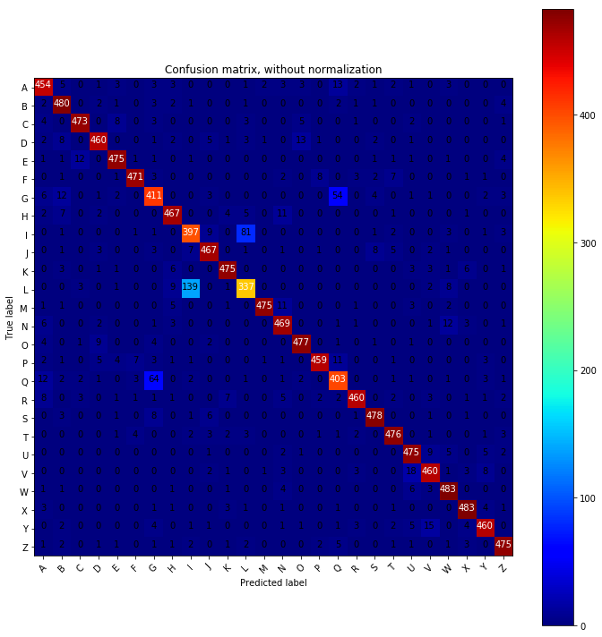

```python
matrix = confusion_matrix(Y_test.argmax(axis=1), y_pred2)
class_names=["A","B","C","D","E","F","G","H","I","J","K","L","M","N","O","P","Q","R","S","T","U","V","W","X","Y","Z"]
#Plot non-normalized confusion matrix
plt.figure(figsize=(10,10))
plot_confusion_matrix(matrix, classes=class_names, title='Confusion matrix, without normalization')
plt.show()
```

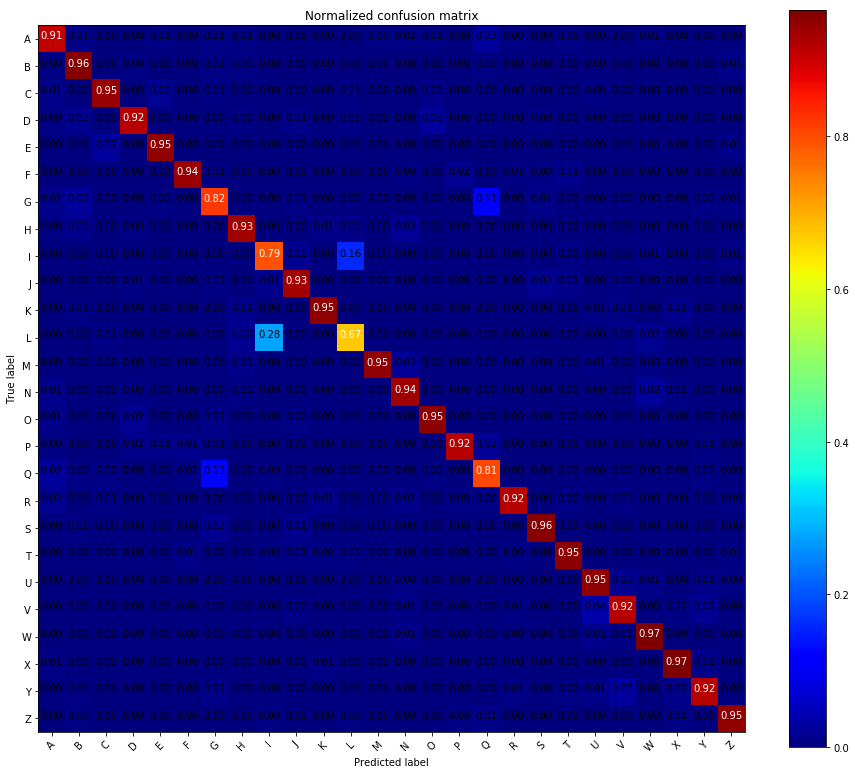

```python
#Plot normalized confusion matrix
plt.figure(figsize=(13,11))
plot_confusion_matrix(matrix, classes=class_names, normalize=True, title='Normalized confusion matrix')
plt.show()
```

Исходя из результатов матрицы, можно сказать, что чаще всего путаются между собой пары букв L и I, Q и G. И это логично, т.к. эти буквы между собой очень схожи. Все буквы определяются примерно с одинаковой точностью, за исключением G, I, L и Q. Самый лучший процент детекции у букв W и X - 97%, а самый худший у буквы L-67%. Наши фамилии начинаются с букв P и R. Они имеют точность детекции 92%. Модель чаще всего путает P с буквой Q, а R с буквой A.

# Цветовая карта нейронов

# Модель без скрытых слоёв

```python
N, M = X_train.shape
O = 26
batch_size = 1000
training_epochs = 20

model = Sequential()
model.add(Dense(O, activation = "softmax", input_shape=(M, )))
model.compile(optimizer='rmsprop', loss='categorical_crossentropy', metrics=['accuracy'])
model.fit(X_train, Y_train, epochs=training_epochs, batch_size=batch_size)
model.evaluate(X_test, Y_test, batch_size=batch_size)
model.summary()
```

```
_________________________________________________________________
Layer (type)                 Output Shape              Param #
=================================================================
dense_30 (Dense)             (None, 26)                20410
=================================================================
Total params: 20,410
Trainable params: 20,410
Non-trainable params: 0
_________________________________________________________________
```

```
Label: 3 Letter: С
```

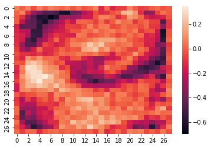

```
Label: 9 Letter: I
```

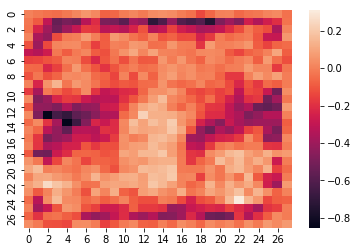

```
Label: 19 Letter: S
```

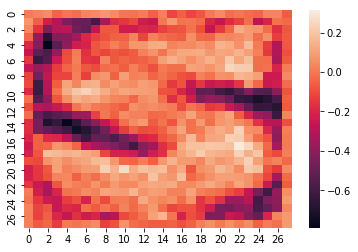

```
Label: 22 Letter: V
```

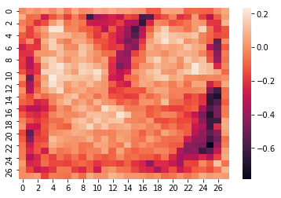

```
Label: 24 Letter: X
```

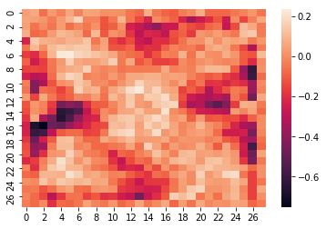

```python
letters=[2,8,18,21,23]
letters_=['С','I','S','V','X']
for let in range(len(letters)):
    weights=model.layers[0].get_weights()[0]
    print('Label:',letters[let]+1,'Letter:',letters_[let])
    Letter_map=weights[:,letters[let]].reshape(28,28)
    seaborn.heatmap(Letter_map.T)
    plt.show()
```

Исходя из полученных цветовых карт, можно сделать вывод что паттерны детекции входов давольно четко демонстрируют букву, которую мы предсказываем.

# Сравнение с другими алгоритмами

Ещё раз считаем Y, т.к. в данном случае не нужно применять to_categorical.

```python
Y_train=train[:,0]
Y_test=test[:,0]
Y_train = np.reshape(Y_train, -1)
Y_test = np.reshape(Y_test, -1)
```

# SVM

1) SVM с коэф-м С=0.01 и rbf ядром. Также перед SVM мы применили PCA с 100 компонентами.

```python
norm = Normalizer()
pca = PCA(n_components=100)
X_train_pca = pca.fit_transform(norm.fit_transform(X_train))
X_test_pca = pca.fit_transform(norm.fit_transform(X_test))

start1=time.perf_counter()

svm = OneVsRestClassifier(SVC(C=0.01, kernel='rbf', probability=True), n_jobs = 1)
svm = svm.fit(X_train_pca, Y_train)

print('SVC score = ', svm.score(X_test_pca, Y_test))

end1=time.perf_counter()
time1=end1-start1
print("Time:",'%.3f' %time1, "seconds")
```

```
SVC score =  0.25876923076923075
Time: 14586.730 seconds
```

2) SVM с коэф-м С=100 и rbf ядром. Также перед SVM мы применили PCA с 10 компонентами.

```python
norm = Normalizer()
pca = PCA(n_components=10)
X_train_pca = pca.fit_transform(norm.fit_transform(X_train))
X_test_pca = pca.fit_transform(norm.fit_transform(X_test))

start1=time.perf_counter()

svm = OneVsRestClassifier(SVC(C=100, kernel='rbf', probability=True), n_jobs = 1)
svm = svm.fit(X_train_pca, Y_train)

print('SVC score = ', svm.score(X_test_pca, Y_test))

end1=time.perf_counter()
time1=end1-start1
print("Time:",'%.3f' %time1, "seconds")
```

```
SVC score =  0.35015384615384615
Time: 13548.540 seconds
```

3) SVM с коэф-м С=100 и rbf ядром. Также перед SVM мы применили PCA с 10 компонентами. На части выборки.

```python
norm = Normalizer()
pca = PCA(n_components=10)
X_train_pca = pca.fit_transform(norm.fit_transform(X_train[:20000]))
X_test_pca = pca.fit_transform(norm.fit_transform(X_test[:5000]))

start1=time.perf_counter()

svm = OneVsRestClassifier(SVC(C=100, kernel='rbf', probability=True), n_jobs = 1)
svm = svm.fit(X_train_pca, Y_train[:20000])
print('SVC score = ', svm.score(X_test_pca, Y_test[:5000]))

end1=time.perf_counter()
time1=end1-start1
print("Time:",'%.3f' %time1, "seconds")
```

```
SVC score =  0.647
Time: 290.920 seconds
```

4) SVM с коэф-м С=100, линейным ядром и с использованием pipeline.

```python
start1=time.perf_counter()

pipeline = Pipeline([
('norm', Normalizer(norm='l2')),
('pca', PCA(n_components=10)),
('svm', SVC(C=100, kernel='linear'))
])
pipeline.fit(X_train, Y_train)
print('SVC score with pipeline =', pipeline.score(X_test, Y_test))

end1=time.perf_counter()
time1=end1-start1
print("Time:",'%.3f' %time1, "seconds")
```

```
SVC score with pipeline = 0.6
Time: 196.119 seconds
```

Ни однин из перечисленных выше методов SVM не дал высокого результата. Среди всех вариантов использовния SVM, лучшим оказался №4, так как он дал относительно хорошую точность предсказания и затратил меньше всего времени.

# Random Forest

Оптимальные параметры мы искали перебором. Но даже лучшие(по нашим меркам), дают результат хуже, чем у нейронок.

```python
start=time.perf_counter()

rf = RandomForestClassifier(n_estimators=90,max_depth=100,min_samples_split=5,max_features='sqrt',n_jobs=-1)
#n_estimators-The number of trees in the forest,will change from 10 to 100.
#max_depth-The maximum depth of the tree.
#min_samples_split-The minimum number of samples required to split an internal node.
#The number of features to consider when looking for the best split.
rf = rf.fit(X_train, Y_train)
print('Random Forest score = ',rf.score(X_test, Y_test))

end=time.perf_counter()
time=end-start
print("Time:",'%.3f' %time, "seconds")
```

```
Random Forest score =  0.8666153846153846
Time: 35.837 seconds
```

Этот алгоритм сработал очень быстро и показал довольно неплохой результат.

# Gradient Boosting

1) Gradient Boosting без корректировки параметров.

```python
start=time.perf_counter()

gbs = GradientBoostingClassifier()
gbs = gbs.fit(X_train, Y_train)
print('Gradient Boosting score = ', gbs.score(X_test, Y_test))

end=time.perf_counter()
time=end-start
print("Time:",'%.3f' %time, "seconds")
```

```
Gradient Boosting score =  0.7806153846153846
Time: 5748.909 seconds
```

2) Gradient Boosting со скоростью обучения, равной 0.01.

```python
start=time.perf_counter()

gbs = GradientBoostingClassifier(learning_rate=0.01)
gbs = gbs.fit(X_train, Y_train)
print('Gradient Boosting score = ', gbs.score(X_test, Y_test))

end=time.perf_counter()
time=end-start
print("Time:",'%.3f' %time, "seconds")
```

```
Gradient Boosting score =  0.5881538461538461
Time: 8600.412 seconds
```

3) Gradient Boosting с максимальной глубиной, равной 6.

```python
start=time.perf_counter()

gbs = GradientBoostingClassifier(max_depth=6)
gbs = gbs.fit(X_train, Y_train)
print('Gradient Boosting score = ', gbs.score(X_test, Y_test))

end=time.perf_counter()
time=end-start
print("Time:",'%.3f' %time, "seconds")
```

```
Gradient Boosting score =  0.8401538461538461
Time: 21436.772 seconds
```

Самую высокую точность имеет 3 вариант бустинга с максимальной глубиной равной 6, но он работает очень долго, поэтому по всем параметрам первый вариант Gradient Boosting является лучшим.

Подводя итог по 3 алгоритмам SVM, Random Forest и Boosting, самым лучшим оказался Random Forest с большим отрывом. Но все же, он уступает нейросетевому подходу по точности.

# Тестирование на своих картинках

Всю обработку картинок мы делали руками в Paint:)) Потому что изначально написали все буквы на одном листе и отсканировали его, поэтому пришлось вырезать каждую букву, переводить в формат 28*28 и обращать цвета.

```python
def read_images_and_predict_letters(name_file,num_letter):
    images = []
    for file in glob(name_file):
        img = np.array(Image.open(file).convert('L'))
        images.append(img.reshape(-1))
        test_img = np.array(images)
    true_labels = np.array([num_letter])
    for im in test_img:
        im = im.T

    batch_size = 5
    y_pred = model2.predict(test_img, batch_size=batch_size)

    n,m = test_img.shape
    for j in range(n):
        plt.imshow(test_img[j].reshape((28, 28)), cmap='gray')
        plt.show()
        print("True label:", true_labels[0])
        print("Predicted label:", y_pred[j].argmax(axis=-1)+1)
```

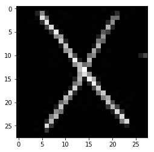

```
True label: 24
Predicted label: 11
```

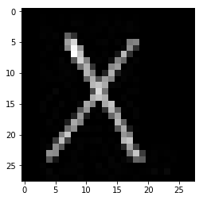

```
True label: 24
Predicted label: 24
```

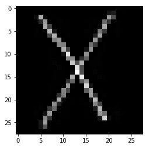

```
True label: 24
Predicted label: 24
```

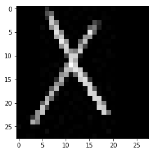

```
True label: 24
Predicted label: 11
```

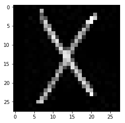

```
True label: 24
Predicted label: 24
```

```python
read_images_and_predict_letters('Буквы2/X/*.png',24)
```

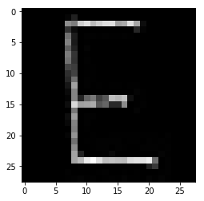

```
True label: 5
Predicted label: 13
```

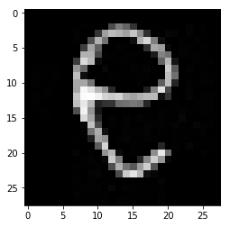

```
True label: 5
Predicted label: 14
```

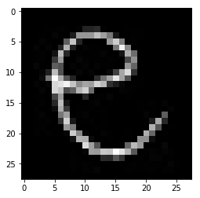

```
True label: 5
Predicted label: 14
```

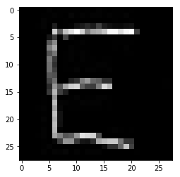

```
True label: 5
Predicted label: 13
```

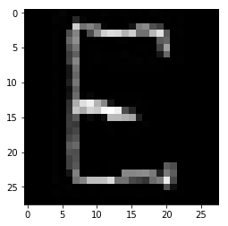

```
True label: 5
Predicted label: 13
```

```python
read_images_and_predict_letters('Буквы2/E/*.png',5)
```

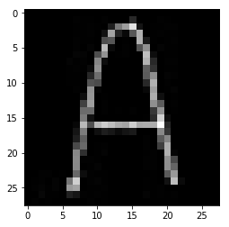

```
True label: 1
Predicted label: 17
```

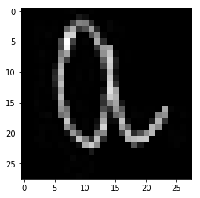

```
True label: 1
Predicted label: 7
```

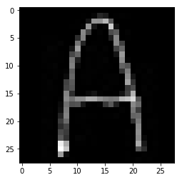

```
True label: 1
Predicted label: 17
```

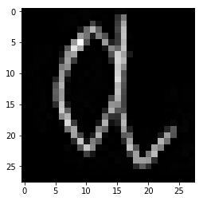

```
True label: 1
Predicted label: 1
```

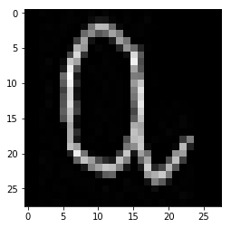

```
True label: 1
Predicted label: 17
```

```python
read_images_and_predict_letters('Буквы2/A/*.png',1)
```

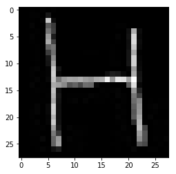

```
True label: 8
Predicted label: 9
```

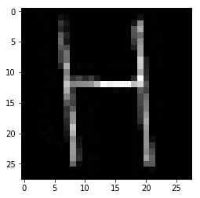

```
True label: 8
Predicted label: 9
```

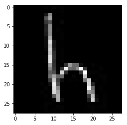

```
True label: 8
Predicted label: 18
```

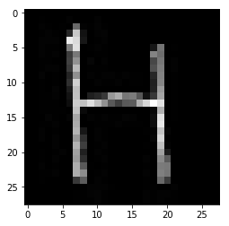

```
True label: 8
Predicted label: 26
```

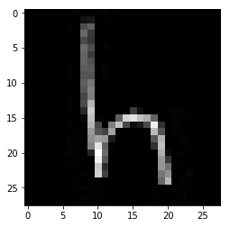

```
True label: 8
Predicted label: 26
```

```python
read_images_and_predict_letters('Буквы2/H/*.png',8)
```

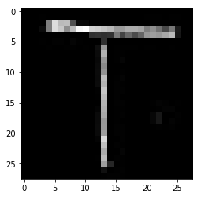

```
True label: 20
Predicted label: 18
```

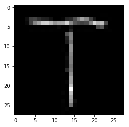

```
True label: 20
Predicted label: 2
```

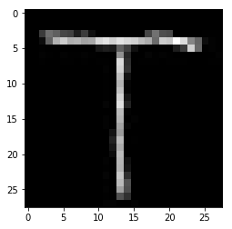

```
True label: 20
Predicted label: 18
```

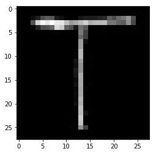

```
True label: 20
Predicted label: 18
```

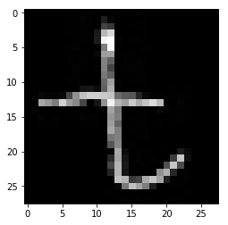

```
True label: 20
Predicted label: 6
```

```python
read_images_and_predict_letters('Буквы2/T/*.png',20)
```

Как видно, результат получается не очень, из 25 букв правильно детектировалось всего 4. Тут мы задумались, почему так получается и решили посмотреть как в изначальных данных нарисованы буквы. Там почерк совсем другой и буквы выглядят иначе. Поэтому мы постарались нарисовать похоже и проверить улучшиться ли результат.

# Буквы, котрые мы старались нарисовать похожими на изначальные данные

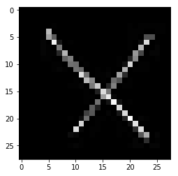

```
True label: 24
Predicted label: 24
```

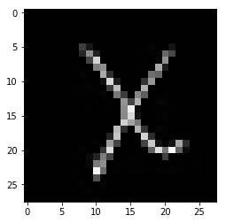

```
True label: 24
Predicted label: 24
```

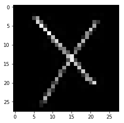

```
True label: 24
Predicted label: 24
```

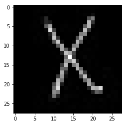

```
True label: 24
Predicted label: 24
```

```python
read_images_and_predict_letters('Буквы2_2часть/X/*.png',24)
```

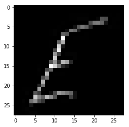

```
True label: 5
Predicted label: 18
```

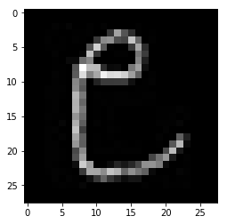

```
True label: 5
Predicted label: 14
```

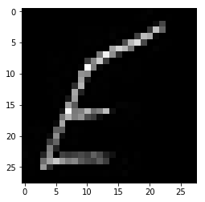

```
True label: 5
Predicted label: 16
```

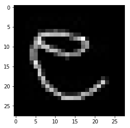

```
True label: 5
Predicted label: 14
```

```python
read_images_and_predict_letters('Буквы2_2часть/E/*.png',5)
```

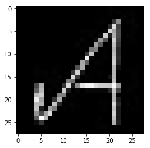

```
True label: 1
Predicted label: 2
```

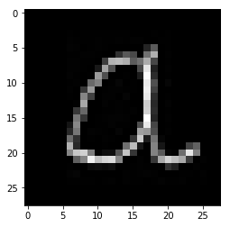

```
True label: 1
Predicted label: 1
```

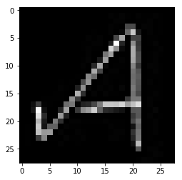

```
True label: 1
Predicted label: 19
```

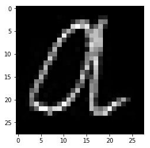

```
True label: 1
Predicted label: 6
```

```python
read_images_and_predict_letters('Буквы2_2часть/A/*.png',1)
```

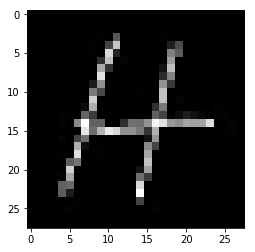

```
True label: 8
Predicted label: 6
```

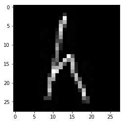

```
True label: 8
Predicted label: 20
```

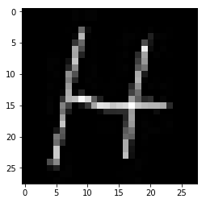

```
True label: 8
Predicted label: 9
```

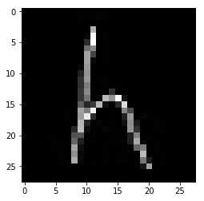

```
True label: 8
Predicted label: 20
```

```python
read_images_and_predict_letters('Буквы2_2часть/H/*.png',8)
```

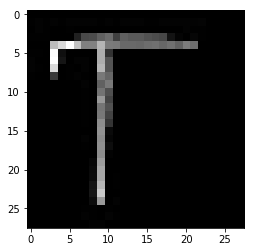

```
True label: 20
Predicted label: 13
```

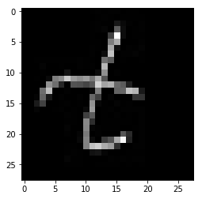

```
True label: 20
Predicted label: 13
```

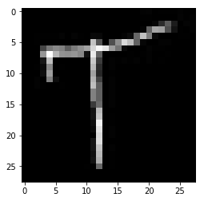

```
True label: 20
Predicted label: 18
```

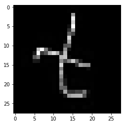

```
True label: 20
Predicted label: 13
```

```python
read_images_and_predict_letters('Буквы2_2часть/T/*.png',20)
```

Такой результат тоже не порадовал. Но мы пытались:)